# Do widowed people have less confidence in science?

April 18, 2015

### Introduction:

Loss of the beloved one produces severely negative experience for everybody. It can change one’s priorities, view of the world and opinions. E.g. one could lose her/his confidence in science if the science failed to save his/her loved one.

In this paper, we will analyze General Social Survey (GSS) data, particullary `marital status` and `confidence in scientific community` variables in order to find out whether widowed people have less confidence in science.

First, we will explore the dataset, plot some graphs and we’ll find the difference between various `marital status` groups. Then we’ll use the statistical methods to measure whether this difference is significant or not. It will turn out that this difference is significant, however we’ll fail to find the cause because of the type of the study.

### Data:

Our data comes from `General Social Survey (GSS)`[1], a sociological survey used to collect data on demographic characteristics and attitudes of residents of the United States.

Data were collected by questionnaires within years 1972 - 2012 (filtered data are from 1973 - 2012). The whole dataset contains 57,061 cases and 114 variables, one case (Unit of observation) describes one interviewee and each variable describes either his/her demographics data or her/his opinions on various topics.

We are interesting in two variables:

1. MARITAL (MARITAL STATUS) - categorical variable
2. CONSCI (CONFIDENCE IN SCIENTIFIC COMMUNITY) - ordinal variable

Since data comes from survey it’s clear an observational study. Full probability sample was used for most of the surveys, one-half block quota was used in the early years, see Appendix A in ICPSR Codebook for further details.

Our population of interest is the whole US population, however the data were collected only from English and Spanish speaking persons 18 years of age or older, living in the United States and thus we can generalize our findings only to that population. Moreover since it is an survey, it may be source of the non-response bias.

Since it’s an observational study we can’t establish any causal links.

One can load the data using this commands (result is in appendix):

```r
library(dplyr)

load(url("http://bit.ly/dasi_gss_data"))

mygss = dplyr::select(gss, marital, consci) %>% na.omit()
```

### Exploratory data analysis:

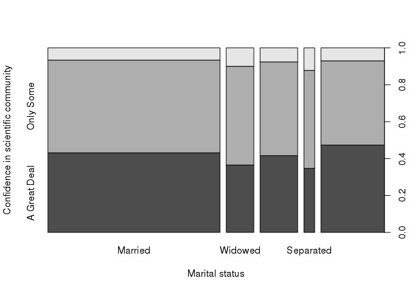

Confidence to science by marital status

```r
with(mygss,
     plot(marital, consci, xlab="Marital status", ylab="Confidence in scientific community")
)
```

As we can see `Widowed` and `Separated` people have clearly lower confidence in science.

We can express this difference also in numbers:

```r
t = with(mygss,
     table(marital, consci)
)
t
```

```
##                consci
## marital         A Great Deal Only Some Hardly Any
##   Married               8522      9923       1306
##   Widowed               1157      1694        316
##   Divorced              1796      2193        328
##   Separated              430       657        151
##   Never Married         3453      3326        512
```

```r
round( prop.table(t, 1), 2)
```

```
##                consci
## marital         A Great Deal Only Some Hardly Any
##   Married               0.43      0.50       0.07
##   Widowed               0.37      0.53       0.10
##   Divorced              0.42      0.51       0.08
##   Separated             0.35      0.53       0.12
##   Never Married         0.47      0.46       0.07
```

`Separated` people have lowest confidence in science followed by `Widowed` people. `Never Married` have highest confidence. It looks like there’s some relation with age. (I did some research beyond scope of this paper and `age` doesn’t explain all of the variance.)

### Inference:

We formulate the null hypothesis and alternative hypothesis:

$H_0$: Marital status and Confidence in science are `independent`. Confidence in science do not vary by Marital status.

$H_A$: Marital status and Confidence in science are `dependent`. Confidence in science do vary by Marital status.

Since we have two categorical variables, we would like to do the Chi-square test of independence test, but we must check the conditions first:

```r
prop.table(table(mygss$consci))
```

```
##
## A Great Deal    Only Some   Hardly Any
##    0.4294262    0.4975115    0.0730623
```

```r
table(mygss$marital)
```

```
##
##       Married       Widowed      Divorced     Separated Never Married
##         19751          3167          4317          1238          7291
```

If $H_0$ is true then each Marital status has 7.3% of people who have `Hardly Any` confidence in science. In `Separated` people (least populated group - 1238 cases) it coresponds to 90 expected cases which is more than required 5.

So now that we satisfied the conditions for chi-square test of independence, let me explain in brief how it works:

We have 2 categorical variables which have `R` and `C` levels respectivelly. Then we have `R*C` scenarios which coresponds to all possible combination of the values. For each scenario we calculate expected counts `E`. We assume the independence in $H_0$ and in independent variables $p(A and B) = p(A)*p(B)$, so we simply multiply two proportions. Then we compare it with observed values `O`. If they were really independent this should by approximatelly 0. We square the difference because we want positive number plus we want to penalize bigger differences. Then we divide it by `E` because we want it to be relative squared difference. Finally we sum all the relative squared differences together and we’ll get chi-squared value. For sure chi-squared summed from larger number of cells will be larger so we must take into account degrees of freedom which is `(R-1)*(C-1)`. From these two values (chi-squared and df) we’ll get the p-value (using corresponding tables or R), which tells us if we should reject $H_0$ or not.

```r
library(MASS)
chisq.test(t)
```

```
##
##  Pearson's Chi-squared test
##
## data:  t
## X-squared = 209.22, df = 8, p-value < 2.2e-16
```

Our p-value is really small which means that we should reject $H_0$ in favour of $H_A$. It means that Marital status and Confidence in science are dependent.

We can now compare `Married` vs `Widowed` in the very same way.

$H_0$: Married people and Widowed people have same confidence in science. Marital status and Confidence in science are `independent` within these two groups.

$H_A$: Marital status and Confidence in science are `dependent` within these two groups.

Again we can check that all conditions are met, minimum expected value is 0.07*3167 = 224 which is greater than 5.

```r
sub = subset(mygss, marital=='Married' | marital=='Widowed')
sub$marital = factor(sub$marital)

prop.table(table(sub$consci))
```

```
##
## A Great Deal    Only Some   Hardly Any
##   0.42233179   0.50689414   0.07077406
```

```r
table(sub$marital)
```

```
##
## Married Widowed
##   19751    3167
```

```r
t2 = table(sub)
chisq.test(t2)
```

```
##
##  Pearson's Chi-squared test
##
## data:  t2
## X-squared = 77.6369, df = 2, p-value < 2.2e-16
```

P-value is again very small, which means that we should reject $H_0$, so we can claim that `Widowed` people have lower Confidence in science compared to `Married` people.

Here we should also mention that no other methods than chi-square testing are applicable, so we can’t calculate the confidence interval and compare the result to the results from hypothesis test.

### Conclusion:

Using chi-square test we showed that Confidence to scientific community depends on the Marital status, i.e. some groups of people have lower and some higher confidence in scientific community. Particularly we showed that Widowed people have lower confidence in science than Married people.

We learned that widowed people have less confidence in science, but we don’t know why. This type of question does not allow us to find any causal links, since experimental study would violate all ethical standards and observational study is not suitable for this.

In future research we can try to find some confounding variables (e.g. age), however as I already mention we will never be able to establish any causal links.

### References

[1] Smith, Tom W., Michael Hout, and Peter V. Marsden. General Social Survey, 1972-2012 [Cumulative File]. ICPSR34802-v1. Storrs, CT: Roper Center for Public Opinion Research, University of Connecticut /Ann Arbor, MI: Inter-university Consortium for Political and Social Research [distributors], 2013-09-11. doi:10.3886/ICPSR34802.v1

data-link: http://bit.ly/dasi_gss_data

codebook-link: https://d396qusza40orc.cloudfront.net/statistics%2Fproject%2Fgss1.html

original dataset: http://www.icpsr.umich.edu/icpsrweb/ICPSR/studies/34802/version/1

### Appendix

```
##            marital       consci
## 1614       Married    Only Some
## 1615       Married A Great Deal
## 1616       Married A Great Deal
## 1617       Married    Only Some
## 1618       Married A Great Deal
## 1619      Divorced A Great Deal
## 1621 Never Married    Only Some
## 1622       Widowed A Great Deal
## 1623       Married    Only Some
## 1624       Widowed A Great Deal
## 1625       Married A Great Deal
## 1627       Married    Only Some
## 1628       Married    Only Some
## 1629       Married A Great Deal
```

[output cut: 36 more lines]